# Problem statement

Videos are a fast growing medium where people communicate, share knowledge, showcase skills etc.

YouTube is one of the biggest platforms which hosts videos. The YouTube platform hosts content from many different professions/arts/ cultures across the world.

People can express their opinion about the video in the form of likes, dislikes, comments which are features provided by the YouTube platform which provides the information on the sentiment about the video.

The assignment involves the steps on programmatic data extraction from YouTube on which analysis can be conducted to understand various attributes related to a video.

Connect to the Youtube API using a Python client

a) Create a YouTube API key

```
steps followed to create API Key:

    1. Login to google developers console
    2. Created a new project named Project Youtube
    3. On Project dashboard, we need to select Explore and Enable API'S
    4. Go to Library and under Youtube API'S select Youtube API v3
    5. Enable the API
    6. Go to credentials and create API key.
    7. We need to restrict it to Youtube Data API v3, Under youtube API'S key restriction.
```

The API key Generated is "AIzaSyBO85t3B23nL0mQ9YnBO6Wz66JsvStg9dU"

# b) Install the Google API python client

pip install google-api-python-client

# 2) Search and extract the data

a) Search videos related to the query string “avatar movie” . (For this part, choose/search one video of your choice and perform data collection steps on that specific video )

Output expected : ID, Snippet, Channel ID, Video Description, Channel Title, Video

```python
import os
import csv
from googleapiclient.discovery import build

# API KEY
api_key = 'AIzaSyBO85t3B23nL0mQ9YnBO6Wz66JsvStg9dU'

# Create a YouTube API service
youtube = build('youtube', 'v3', developerKey=api_key)
```

```python
# Searching videos with query string "avatar movie"
search_response = youtube.search().list(q='avatar movie',type='video',part='id,snippet',maxResults=1).execute()

# Extracting the video details
video_id = search_response['items'][0]['id']['videoId']
video_snippet = search_response['items'][0]['snippet']

# Get more details about the specific video using its ID
video_response = youtube.videos().list(id=video_id,part='snippet,statistics').execute()

# Getting more details
video_description = video_response['items'][0]['snippet']['description']
channel_id = video_response['items'][0]['snippet']['channelId']
channel_title = video_response['items'][0]['snippet']['channelTitle']
view_count = video_response['items'][0]['statistics']['viewCount']

# Printing the data
print(f"Video ID: {video_id}")
print(f"Video Snippet: {video_snippet}")
print(f"Channel ID: {channel_id}")
print(f"Video Description: {video_description}")
print(f"Channel Title: {channel_title}")
print(f"View Count: {view_count}")
```

```
Video ID: w8PmrLG6v5I
Video Snippet: {'publishedAt': '2022-01-18T13:59:07Z', 'channelId': 'UCBOmfqgTZi7yDp4-3Lr_3lA', 'title': 'BOLLYWOOD BLOCKBUSTER HINDI MOVIE - राजेश खन्ना ,शबाना आजमी और सचिन की सुपरहिट हिंदी मूवी - AVTAAR', 'description': 'ShemarooMovies #Hindi #Movie #Bollywood #FullMovie #HD Click here to Subscrib…
Channel ID: UCBOmfqgTZi7yDp4-3Lr_3lA
Video Description: #ShemarooMovies #Hindi #Movie #Bollywood #FullMovie #HD

Click here to Subscribe the channel : http://www.youtube.com/channel/UCBOmfqgTZi7yDp4-3Lr_3lA?annotation_id=annotation_2452002513&sub_confirmation=1

Like, Comment and Share with your friends and family. Watch more Bollywood videos and movies starring your favourite celebrities like Amitabh Bachchan, Raj Kapoor, Dharmendra, Zeenat Aman, Vidya Balan, Govinda, Salman Khan and many more, only on http://www.YouTube.com/ShemarooEnt

SUBSCRIBE for the best Bollywood videos, movies and scenes, all in ONE channel @shemaroomovies

Bollywood ENT
Follow us on:
Facebook - https://www.facebook.com/ShemarooEnt/
Twitter - https://twitter.com/ShemarooEnt Instagram - https://www.instagram.com/shemarooent/?hl=en

Bollywood Comedy
Follow us on:
Facebook - Follow us on https://www.facebook.com/Comedywalas/
Twitter - https://twitter.com/ShemarooComedy Instagram - https://www.instagram.com/shemaroocomedy/?hl=en

Bollywood Music
Follow us on:
Facebook - Follow us on https://www.facebook.com/ShemarooFilmiGaane/
Twitter - https://twitter.com/FilmiGaane Instagram - https://www.instagram.com/shemaroofilmigaane/?hl=en

ShemarooMe : https://shemaroome.onelink.me/ilnR/yt3
Facebook - https://www.facebook.com/ShemarooEnt Twitter - https://twitter.com/ShemarooEnt
SUBSCRIBE for the best Bollywood videos, movies and scenes, all in ONE channel http://www.YouTube.com/ShemarooEnt
Channel Title: Shemaroo Movies
View Count: 8493062
```

# b) Provide the following statistics for query string “avatar movie” of top 50 videos sorted by relevance in the US region (regionCode)

```python
# Searching for top 50 videos for the string "avatar movie"
search_response = youtube.search().list(q='avatar movie',type='video',part='id,snippet',maxResults=50, regionCode='US',
                                        order='relevance').execute()

# Prepare CSV file for writing
csv_file = open('avatarmovie_statistics.csv', 'w', newline='', encoding='utf-8')
csv_writer = csv.writer(csv_file)
csv_writer.writerow(['Video ID', 'Title', 'no of Views', 'no of Likes', 'no of Comments'])

for item in search_response['items']:
    video_id = item['id']['videoId']
    video_snippet = item['snippet']

    # Getting the statistics for the videos
    video_response = youtube.videos().list(id=video_id,part='snippet,statistics').execute()
    video_statistics = video_response['items'][0]['statistics']

    # Extracting the data
    Title = video_snippet['title']
    no_of_views = video_statistics.get('viewCount', 0)
    no_of_likes = video_statistics.get('likeCount', 0)
    no_of_comments = video_statistics.get('commentCount', 0)

    # Writing the data to csv
    csv_writer.writerow([video_id, Title, no_of_views, no_of_likes, no_of_comments])

# Closing the csv file
csv_file.close()

print("Successfully completed")
```

```
Successfully completed
```

# 3) Analyze the exported data obtained in 2.b and carry out the following tasks

```python
# First we need to read the data which we extracted and perform the analysis.
# Then import necessary libraries for the data analysis


import pandas as pd
import numpy as np

# Reading the data

data = pd.read_csv("avatarmovie_statistics.csv", header=0)
```

# Understanding the data

```python
# dimensions of the data

data.shape
```

```
(50, 5)
```

```python
# Looking at the first five rows or head of the data
data.head()
```

|  | Video ID | Title | no of Views | no of Likes | no of Comments |
| --- | --- | --- | --- | --- | --- |
| 0 | PLtgIILX7E8 | AVATAR Full Movie 2023: Fallen Kingdom \| Super... | 28561978 | 146140 | 906 |
| 1 | d9MyW72ELq0 | Avatar: The Way of Water \| Official Trailer | 57455160 | 1043545 | 43365 |
| 2 | 6pHZmBin4Xc | Toruk Macto - AVATAR (4k Movie Clip) | 1667282 | 14077 | 385 |
| 3 | 5PSNL1qE6VY | Avatar \| Official Trailer (HD) \| 20th Century FOX | 12670954 | 80893 | 8942 |
| 4 | mdhEj_rG80Y | AVATAR - Movie Behind the Scenes \| Making of | 1521185 | 5106 | 88 |

```python
# Looking at the last five rows or tail of the data
data.tail()
```

|  | Video ID | Title | no of Views | no of Likes | no of Comments |
| --- | --- | --- | --- | --- | --- |
| 45 | nsO1isT60h8 | Destruction of Home Tree - AVATAR (4k Movie Clip) | 361224 | 2987 | 504 |
| 46 | yRR1K9dmhxw | Behind the scenes of Avatar, Zoe Saldana and S... | 5760687 | 244859 | 940 |
| 47 | Z5u4fqNIo74 | Now you’re in the stars🤍 #avatar #avatar2 #ava... | 468350 | 48465 | 805 |
| 48 | cN0kUKNBfxE | Avatar 2009 - The Final Battle - Best Fight Sc... | 3151437 | 27028 | 639 |
| 49 | 3x0rDYAWdF4 | last one for today :) #foryoupage #zbcxya #ily... | 4087642 | 274921 | 1297 |

```python
# summary statistics

data.describe(include="all")
```

|  | Video ID | Title | no of Views | no of Likes | no of Comments |
| --- | --- | --- | --- | --- | --- |
| count | 50 | 50 | 5.000000e+01 | 5.000000e+01 | 50.000000 |
| unique | 50 | 50 | NaN | NaN | NaN |
| top | PLtgIILX7E8 | AVATAR Full Movie 2023: Fallen Kingdom \| Super... | NaN | NaN | NaN |
| freq | 1 | 1 | NaN | NaN | NaN |
| mean | NaN | NaN | 5.956243e+06 | 1.087498e+05 | 2466.740000 |
| std | NaN | NaN | 1.125760e+07 | 2.249328e+05 | 7277.952094 |
| min | NaN | NaN | 7.100000e+01 | 0.000000e+00 | 0.000000 |
| 25% | NaN | NaN | 4.026732e+05 | 5.401750e+03 | 243.000000 |
| 50% | NaN | NaN | 1.263305e+06 | 1.878500e+04 | 550.500000 |
| 75% | NaN | NaN | 4.328270e+06 | 8.005900e+04 | 1221.000000 |
| max | NaN | NaN | 5.745516e+07 | 1.043545e+06 | 43365.000000 |

```python
# checking the null values if any

data.isnull().sum()
```

```
Video ID          0
Title             0
no of Views       0
no of Likes       0
no of Comments    0
dtype: int64
```

```python
# checking the data types

data.dtypes
```

```
Video ID          object
Title             object
no of Views        int64
no of Likes        int64
no of Comments     int64
dtype: object
```

# Visualizing the data

```python
import seaborn as sns
import matplotlib.pyplot as plt
```

[output not shown]

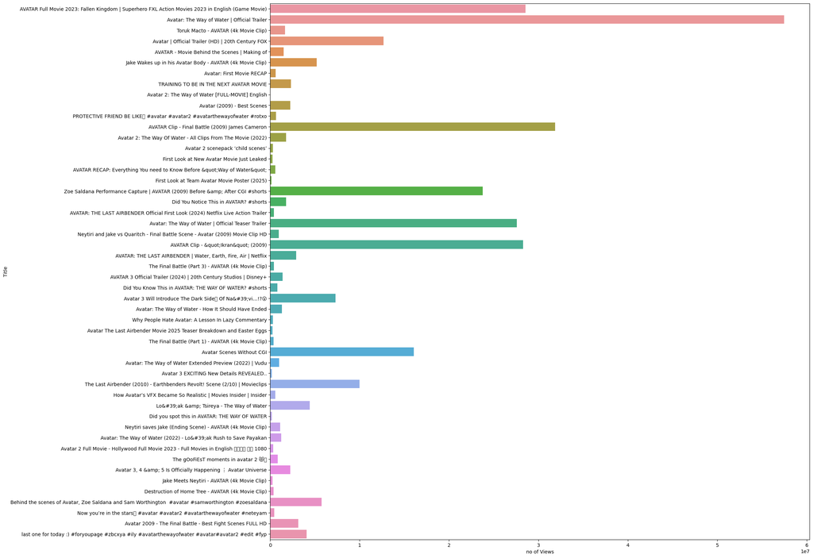

```python
plt.figure(figsize=(20,20))
sns.barplot(x='no of Views',y='Title',data=data)
```

[output not shown]

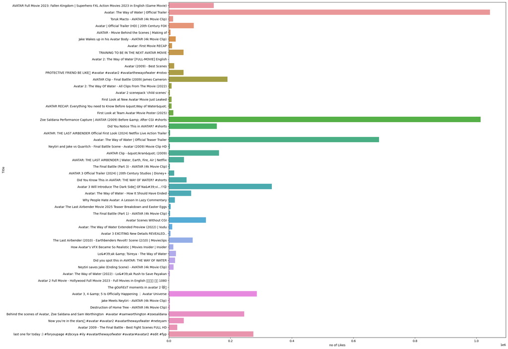

```python
plt.figure(figsize=(20,20))
sns.barplot(x='no of Likes',y='Title',data=data)
```

```
(-1.0999990443310996,
 1.0999998856127828,
 -1.0999999998897765,
 1.0999999976853077)
```

[figure not shown]

```python
plt.figure(figsize=(8,8))
plt.pie(data['no of Views'], labels=data["Title"],autopct='%1.1f%%', startangle=140)
plt.title('Sample Pie Chart')
plt.axis('equal')
```

# a) Sort the data 2.b by top 10 comments in descending order and consider the video IDs and Titles of top 10 videos which have highest comments.

```python
sorted_data = data.sort_values(by='no of Comments', ascending=False).head(10)
```

```python
sorted_data.head(10)
```

|  | Video ID | Title | no of Views | no of Likes | no of Comments |
| --- | --- | --- | --- | --- | --- |
| 1 | d9MyW72ELq0 | Avatar: The Way of Water \| Official Trailer | 57455160 | 1043545 | 43365 |
| 20 | a8Gx8wiNbs8 | Avatar: The Way of Water \| Official Teaser Tra... | 27562810 | 683311 | 29184 |
| 3 | 5PSNL1qE6VY | Avatar \| Official Trailer (HD) \| 20th Century FOX | 12670954 | 80893 | 8942 |
| 27 | f5Zx8iPek5I | Avatar 3 Will Introduce The Dark Side🔥 Of Na&#... | 7313331 | 334590 | 3824 |
| 11 | 0sJeBiUCIt4 | AVATAR Clip - Final Battle (2009) James Cameron | 31878066 | 190337 | 3666 |
| 23 | QOg9LUIvaig | AVATAR: THE LAST AIRBENDER \| Water, Earth, Fir... | 2891842 | 49322 | 3580 |
| 29 | RGx8rYbRVR4 | Why People Hate Avatar: A Lesson In Lazy Comme... | 294364 | 19859 | 3193 |
| 17 | kHNCaWjB-98 | Zoe Saldana Performance Capture \| AVATAR (2009... | 23776760 | 1013533 | 3144 |
| 28 | rM8ogjwity8 | Avatar: The Way of Water - How It Should Have ... | 1305912 | 72199 | 2336 |
| 22 | ZM2k1UmcCXg | AVATAR Clip - &quot;Ikran&quot; (2009) | 28285739 | 162900 | 2199 |

```python
print(sorted_data['Video ID'])
```

```
1     d9MyW72ELq0
20    a8Gx8wiNbs8
3     5PSNL1qE6VY
27    f5Zx8iPek5I
11    0sJeBiUCIt4
23    QOg9LUIvaig
29    RGx8rYbRVR4
17    kHNCaWjB-98
28    rM8ogjwity8
22    ZM2k1UmcCXg
Name: Video ID, dtype: object
```

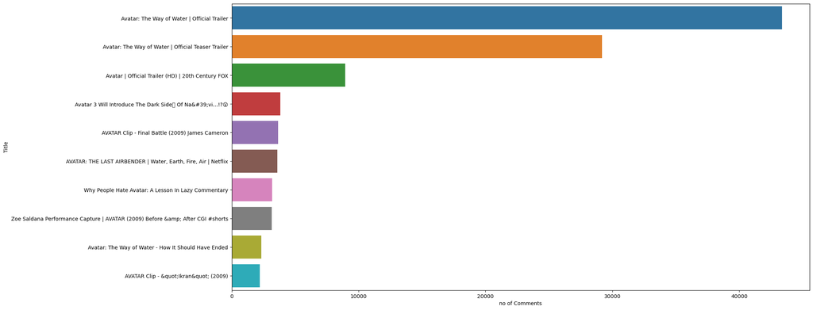

```python
plt.figure(figsize=(20,10))
sns.barplot(x='no of Comments',y='Title',data=sorted_data)
```

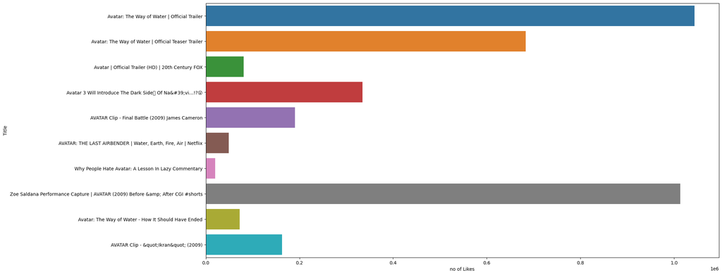

```python
plt.figure(figsize=(20,10))
sns.barplot(x='no of Likes',y='Title',data=sorted_data)
```

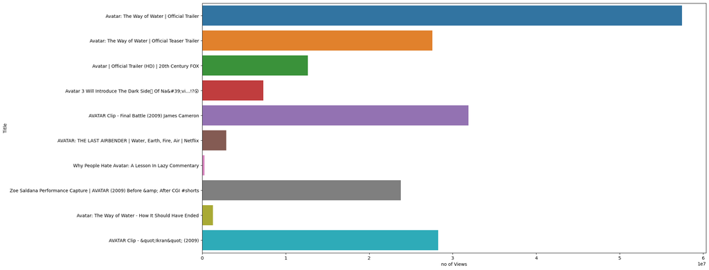

```python
plt.figure(figsize=(20,10))
sns.barplot(x='no of Views',y='Title',data=sorted_data)
```

# b) Use a suitable method to retrieve comments of those top 10 videos from 3.a. Fordoing this, write a program to loop through each video id from 3.a and pass in the partparameter set to "snippet", to retrieve basic details about the comments. Execute thisrequest and print the response using the pprint() method. Note: pprint() will print out the response from the API in a more human-readableformat.

# Output expected : Use the python library “ pprint “ to print the output ofthe program with the following properties etag, items, id , kind snippet and snippet to have the text display field which represents the comment of videos

```python
import requests
from pprint import pprint

API_KEY = 'AIzaSyBO85t3B23nL0mQ9YnBO6Wz66JsvStg9dU'

# creating a list of videoID's
video_ids = [
      'd9MyW72ELq0','a8Gx8wiNbs8','5PSNL1qE6VY','f5Zx8iPek5I','0sJeBiUCIt4','QOg9LUIvaig','RGx8rYbRVR4',
      'kHNCaWjB-98','rM8ogjwity8','ZM2k1UmcCXg'
   ]

# Initializing the base URL
base_url = 'https://www.googleapis.com/youtube/v3/'

# writing a loop through each videoID
for video_id in video_ids:
    params = {
        'part': 'snippet',
        'videoId': video_id,
        'key': API_KEY,
        'textFormat': 'plainText',
        'maxResults': 10,
    }

    # API request
    response = requests.get(base_url + 'commentThreads', params=params)
    data = response.json()

    # Print the response using pprint
    pprint(data)

    # for loop to extract the comments from the 'data' dictionary
    for item in data.get('items', []):
        comments = item['snippet']['topLevelComment']['snippet']['textDisplay']
        print(comments)
```

```
{'etag': '8NGHN9mFfKl7IWuuiH73zFUGf2Q',
 'items': [{'etag': 'kGsQEaB1v2Ge95kvHEcBIYBDjq4',
            'id': 'UgwgzHz1m73lrRQDal94AaABAg',
            'kind': 'youtube#commentThread',
            'snippet': {'canReply': True,
                        'isPublic': True,
                        'topLevelComment': {'etag': 'AbbGz1T8U1CDoj7yEcl_DYM7Aao',
                                            'id': 'UgwgzHz1m73lrRQDal94AaABAg',
                                            'kind': 'youtube#comment',
                                            'snippet': {'authorChannelId': {'value': 'UCnAqeKVHokgPwDzI9wYnkaw'},
                                                        'authorChannelUrl': 'http://www.youtube.com/channel/UCnAqeKVHokgPwDzI9wYnkaw',
                                                        'authorDisplayName': 'P '
                                                                             'CH',
                                                        'authorProfileImageUrl': 'https://yt3.ggpht.com/22M6oxT9rBMJg0kDt_ZYt2Eb7spZktopraDP6p9sBKdwklUAyqKOrSrJlWBhvLv7d3tFRbHUFw=s48-c-k-c0x00ffffff-no-rj',
                                                        'canRate': True,
                                                        'likeCount': 0,
                                                        'publishedAt': '2023-08-08T09:53:24Z',
                                                        'textDisplay': 'I want '
                                                                       'ang',
                                                        'textOriginal': 'I '
                                                                        'want '
                                                                        'ang',
                                                        'updatedAt': '2023-08-08T09:53:24Z',
                                                        'videoId': 'd9MyW72ELq0',
                                                        'viewerRating': 'none'}},
                        'totalReplyCount': 0,
                        'videoId': 'd9MyW72ELq0'}},
           {'etag': 'zTjIoZNY0awcR_htx15LDrOao08',
            'id': 'UgwFvrQz6Pc7qWDm3hl4AaABAg',
            'kind': 'youtube#commentThread',
            'snippet': {'canReply': True,
                        'isPublic': True,
                        'topLevelComment': {'etag': '1-F6LSrZrgEhYe6FL6JS29eQCGk',
                                            'id': 'UgwFvrQz6Pc7qWDm3hl4AaABAg',
                                            'kind': 'youtube#comment',
                                            'snippet': {'authorChannelId': {'value': 'UCq5vkHNNHKXrSuQmTZsBn7A'},
                                                        'authorChannelUrl': 'http://www.youtube.com/channel/UCq5vkHNNHKXrSuQmTZsBn7A',
                                                        'authorDisplayName': 'JFIFFL',
                                                        'authorProfileImageUrl': 'https://yt3.ggpht.com/JgmfpApP4hJxfarkEv7fcXO8I33tB7BcpKLS7TxNSuau0EWTPz0NK-mx8MT-YVub32Pm16_2Iw=s48-c-k-c0x00ffffff-no-rj',
                                                        'canRate': True,
```

[output cut: 5333 more lines]

```
 'kind': 'youtube#commentThreadListResponse',
 'nextPageToken': 'QURTSl9pMk1OZFFfZHVhMm1YVjRHVGdrXzdDeVBQaTZyRGpJRWQ0emtnNHR3YWV6aU5nNUh2M2pwcGVLZzd1REdBWHpkUDZVeVROS0JFUQ==',
 'pageInfo': {'resultsPerPage': 10, 'totalResults': 10}}
The way he said “SHUT UP AND FLY STRAIGHT”
Who else came here to hear Tsu’tey’s laugh?
0:09 Pokemon and ARK.
Jake: Gardevoir
Ikran: desmodus
Nice
I want to know this native language at 0:50
Savage ikran literally just smacked Jake in the head 1:39
NABIN
1:30 just realized he put it in a fuckin sleeper hold and it worked 😂
This is my first time to see these movies, this whole movie make me feel a boi again,
Agreed horses are assholes lol jk I love horses
```

# c) Write a program to export the output of question 3.b in JSON file format and submit the file as part of the assignment

```python
import json

# using json.dumps() to convert it to json string
json_data = json.dumps(data, indent=4)

# Writing to JSON
with open('3b_output.json', 'w') as json_file:
    json_file.write(json_data)
```

# d) Write a function to get the likes vs views ratio of the top 10 videos obtained in 3.a with the highest comments

```python
import pandas as pd

def ratio(sorted_data, numerator_col, denominator_col):

    ratios = sorted_data[numerator_col] / sorted_data[denominator_col]
    return ratios

result = ratio(sorted_data, 'no of Likes', 'no of Views')
print(result)
```

```
1     0.018163
20    0.024791
3     0.006384
27    0.045751
11    0.005971
23    0.017056
29    0.067464
17    0.042627
28    0.055286
22    0.005759
dtype: float64
```